# R Workshop

# 10 Data Aggregation

Summary statistics can be computed with `tapply`, `aggregate`, and `Hmisc::summarize`.

```r
getHdata(DominicanHTN)
contents(DominicanHTN)
```

```
Data frame:DominicanHTN 381 observations and 5 variables    Maximum # NAs:0

                          Labels Units Levels Storage
village                                     8 integer
gender                                      2 integer
age                                           integer
sbp      Systolic Blood Pressure  mmHg        integer
dbp     Diastolic Blood Pressure  mmHg        integer

+--------+------------------------------------------------------------------+
|Variable|Levels                                                            |
+--------+------------------------------------------------------------------+
| village|Bare' Nuevo,Batey Verde,Carmona,Cojobal,Juan Sanchez,La Altagracia|
|        |Los Gueneos,San Antonio                                           |
+--------+------------------------------------------------------------------+
| gender |Female,Male                                                       |
+--------+------------------------------------------------------------------+
```

```r
# calculate mean age by village
with(DominicanHTN, tapply(age, village, mean))
```

```
  Bare' Nuevo   Batey Verde       Carmona       Cojobal  Juan Sanchez La Altagracia
     47.53125      48.02439      49.00000      47.15254      47.45283      49.65000
  Los Gueneos   San Antonio
     45.15789      51.25714
```

```r
# calculate mean sbp by gender
aggregate(sbp ~ gender, data=DominicanHTN, FUN=mean)
```

```
  gender      sbp
1 Female 133.1977
2   Male 132.5691
```

```r
# calculate median age by village and gender
aggregate(age ~ village + gender, DominicanHTN, median)
```

```
         village gender  age
1    Bare' Nuevo Female 40.0
2    Batey Verde Female 43.0
3        Carmona Female 40.0
4        Cojobal Female 43.0
5   Juan Sanchez Female 47.0
6  La Altagracia Female 48.0
7    Los Gueneos Female 40.0
8    San Antonio Female 42.5
9    Bare' Nuevo   Male 48.0
10   Batey Verde   Male 52.0
11       Carmona   Male 53.0
12       Cojobal   Male 49.0
13  Juan Sanchez   Male 56.0
14 La Altagracia   Male 57.5
15   Los Gueneos   Male 51.0
16   San Antonio   Male 61.0
```

```r
# calculate quantile of sbp by village and gender
with(DominicanHTN, summarize(sbp, llist(village, gender), quantile))
```

```
         village gender sbp  X25.  X50.   X75. X100.
1    Bare' Nuevo Female  80 125.0 130.0 141.00   166
2    Bare' Nuevo   Male 102 120.0 126.0 136.00   148
3    Batey Verde Female 110 120.0 132.0 155.00   190
4    Batey Verde   Male  90 117.0 130.0 147.50   180
5        Carmona Female  95 114.0 130.0 150.00   204
6        Carmona   Male 100 120.0 130.0 150.00   168
7        Cojobal Female  90 119.0 124.0 150.00   200
8        Cojobal   Male  90 116.0 122.0 134.00   200
9   Juan Sanchez Female 100 118.0 130.0 140.00   200
10  Juan Sanchez   Male  90 120.0 130.0 150.00   200
11 La Altagracia Female  90 118.0 125.0 156.00   210
12 La Altagracia   Male  80 112.0 120.0 137.00   236
13   Los Gueneos Female  90 106.0 118.0 140.00   180
14   Los Gueneos   Male  98 118.0 124.5 144.75   170
15   San Antonio Female  90 116.5 129.5 150.00   190
16   San Antonio   Male 100 125.0 140.0 165.00   210
```

# 11 Formulas

The previous `aggregate` example introduced the `~` operator. The tilde is used to create a model formula, which consists of a left-hand side and right-hand side. Many R functions utilize formulas, such as plotting functions and model-fitting functions. The left-hand side consists of the response variable, while the right-hand side may contain several terms. You may see the following operators within a formula.

- y ~ a + b, `+` indicates to include both a and b as terms
- y ~ a:b, `:` indicates the interaction of a and b
- y ~ a*b, equivalent to y ~ a+b+a:b
- y ~ (a+b)^2, equivalent to y ~ (a+b)*(a+b)
- y ~ a + I(b+c), `I` indicates to use `+` in the arithmetic sense

See ?formula for more examples.

# 12 Models

The most simple model-fitting function is `lm`, which is used to fit linear models. It’s primary argument is a formula. Using the DominicanHTN data set, we can fit sbp by age.

```r
(m <- lm(sbp ~ age, data=DominicanHTN))
```

```
Call:
lm(formula = sbp ~ age, data = DominicanHTN)

Coefficients:
(Intercept)          age
   108.3079       0.5146
```

This creates an `lm` object, and several functions can be used on model objects. The internal structure of a model object is a list - its elements may be accessed just like a list.

- coef
- fitted
- predict
- residuals
- vcov
- summary
- anova

```r
names(m)
```

```
 [1] "coefficients"  "residuals"     "effects"       "rank"          "fitted.values"
 [6] "assign"        "qr"            "df.residual"   "xlevels"       "call"
[11] "terms"         "model"
```

```r
m$coefficients
```

```
(Intercept)         age
108.3078571   0.5146198
```

```r
coef(m)
```

```
(Intercept)         age
108.3078571   0.5146198
```

```r
head(fitted(m))
```

```
Systolic Blood Pressure [mmHg]
       1        2        3        4        5        6
137.1266 129.9219 143.8166 144.3312 140.2143 140.7289
```

```r
predict(m, data.frame(age=c(40, 60)))
```

```
       1        2
128.8926 139.1850
```

```r
head(residuals(m))
```

```
Systolic Blood Pressure [mmHg]
         1          2          3          4          5          6
 12.873433  -9.921890 -23.816625  35.668756  -2.214286 -25.728906
```

```r
vcov(m)
```

```
            (Intercept)          age
(Intercept)  17.5571859 -0.333034803
age          -0.3330348  0.006942401
```

```r
summary(m)
```

```
Call:
lm(formula = sbp ~ age, data = DominicanHTN)

Residuals:
Systolic Blood Pressure [mmHg]
    Min      1Q  Median      3Q     Max
-63.080 -16.688  -2.787  11.961  96.815

Coefficients:
             Estimate Std. Error t value Pr(>|t|)
(Intercept) 108.30786    4.19013  25.848  < 2e-16 ***
age           0.51462    0.08332   6.176 1.69e-09 ***
---
Signif. codes:  0 '***' 0.001 '**' 0.01 '*' 0.05 '.' 0.1 ' ' 1

Residual standard error: 24.54 on 379 degrees of freedom
Multiple R-squared:  0.09145,   Adjusted R-squared:  0.08905
F-statistic: 38.15 on 1 and 379 DF,  p-value: 1.692e-09
```

```r
coef(summary(m))
```

```
               Estimate Std. Error   t value     Pr(>|t|)
(Intercept) 108.3078571 4.19012958 25.848331 1.177025e-85
age           0.5146198 0.08332107  6.176347 1.691868e-09
```

```r
anova(m)
```

```
Analysis of Variance Table

Response: sbp
           Df Sum Sq Mean Sq F value    Pr(>F)
age         1  22980 22980.3  38.147 1.692e-09 ***
Residuals 379 228314   602.4
---
Signif. codes:  0 '***' 0.001 '**' 0.01 '*' 0.05 '.' 0.1 ' ' 1
```

# 13 R Graphics with ggplot2

The examples [here](http://www.statmethods.net/advgraphs/ggplot2.html) (“9,” n.d.) say it best.

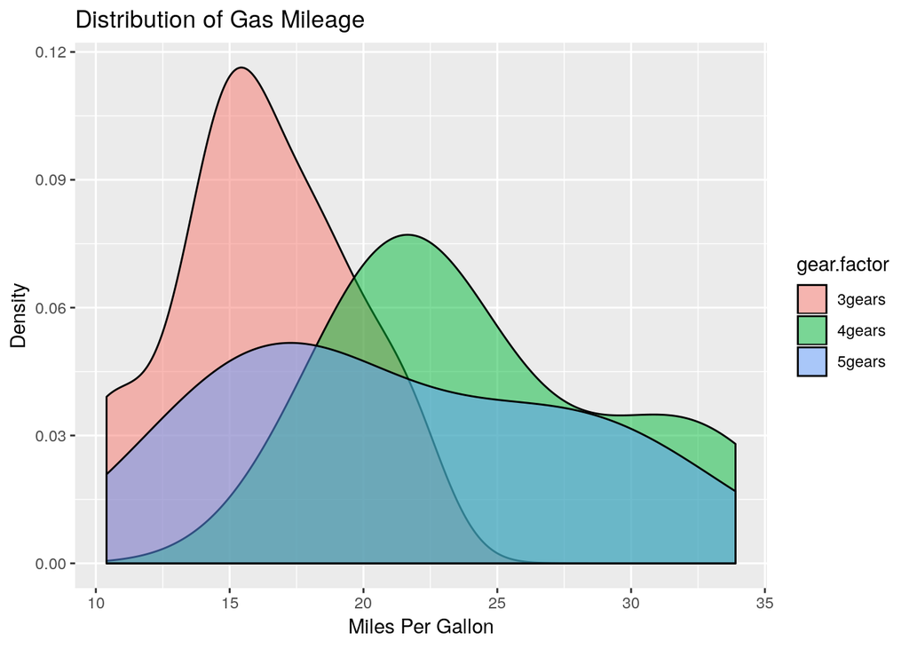

```r
library(ggplot2)
# create factors, categorical variables
m2 <- within(mtcars, {
    gear.factor <- factor(gear, levels=c(3,4,5), labels=c("3gears","4gears","5gears"))
    am.factor <- factor(am, levels=c(0,1), labels=c("Automatic","Manual"))
    cyl.factor <- factor(cyl, levels=c(4,6,8), labels=c("4cyl","6cyl","8cyl"))
})

# kernel density
qplot(mpg, data=m2, geom="density", fill=gear.factor, alpha=I(.5),
      main="Distribution of Gas Mileage", xlab="Miles Per Gallon", ylab="Density"
)
```

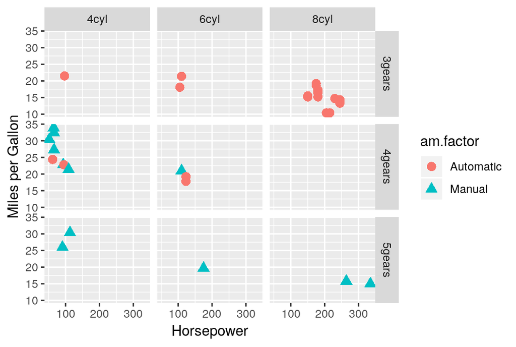

```r
# scatterplot
qplot(hp, mpg, data=m2, shape=am.factor, color=am.factor,
      facets=gear.factor~cyl.factor, size=I(3), xlab="Horsepower",
      ylab="Miles per Gallon"
)
```

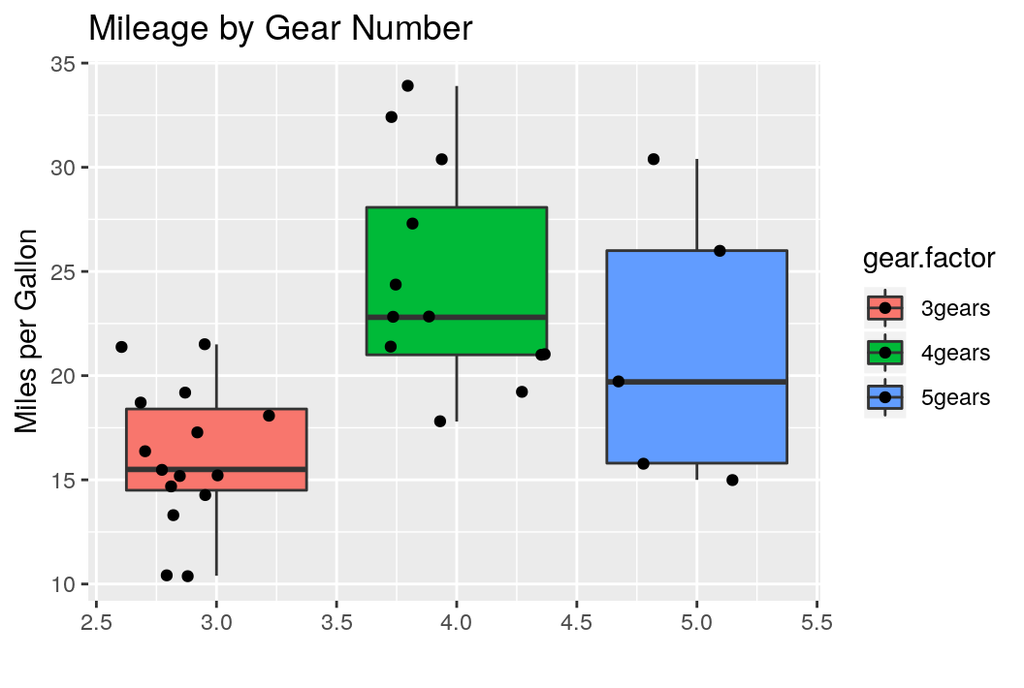

```r
# boxplot
qplot(gear, mpg, data=m2, geom=c("boxplot", "jitter"), fill=gear.factor,
      main="Mileage by Gear Number", xlab="", ylab="Miles per Gallon"
)
```

Example with regression:

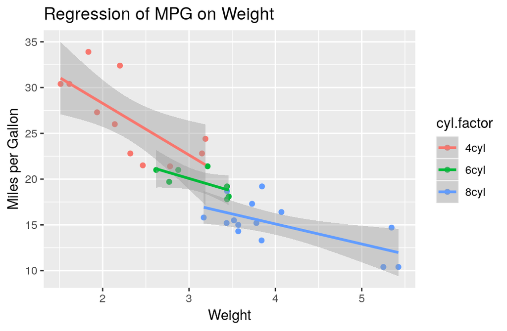

```r
# scatterplot
p <- qplot(wt, mpg, data=m2, color=cyl.factor,
      main="Regression of MPG on Weight", xlab="Weight", ylab="Miles per Gallon"
)
# add regression line
p + geom_smooth(method="lm")
```

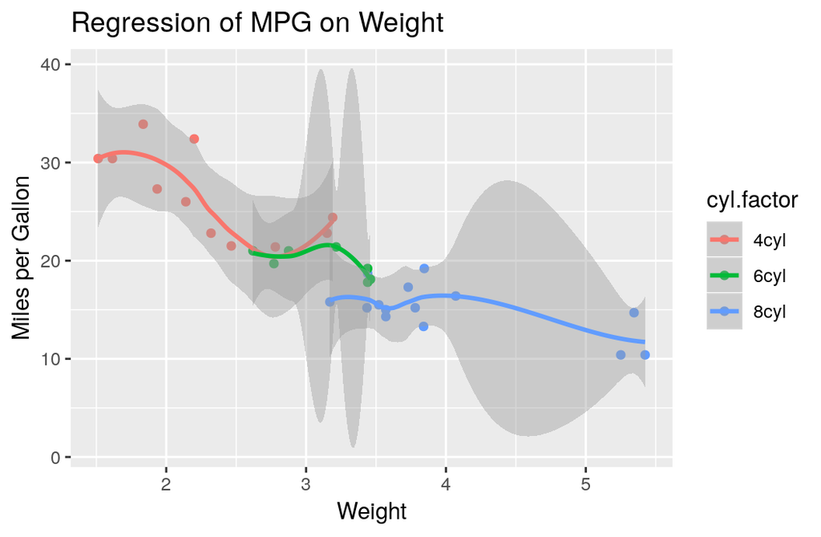

```r
p + geom_smooth(method="loess")
```

## 13.1 Graphics Devices

Plots created with `ggplot2` can be saved to a file with the `ggsave` function. The file format is determined by the file name. Some are vector file formats (pdf, svg), while others (bmp, jpeg, png) are raster formats. Vector files can be scaled without pixelation.

Create 6“x6” png at 300 dpi, useful for print publications:

```r
qplot(hp, mpg, data=m2, shape=am.factor, color=am.factor,
      facets=gear.factor~cyl.factor, size=I(3), xlab="Horsepower",
      ylab="Miles per Gallon"
)
```

```r
ggsave("mileageByHorses.png", width=6, height=6, dpi=300)
```

Plot to PDF:

```r
qplot(gear, mpg, data=m2, geom=c("boxplot", "jitter"), fill=gear.factor,
            main="Mileage by Gear Number", xlab="", ylab="Miles per Gallon")
```

```r
ggsave("mileageByGear.pdf")
```

# Links

“1.” n.d. http://miktex.org/download.

“2.” n.d. http://www.tug.org/mactex/morepackages.html.

“3.” n.d. http://yihui.name/knitr/.

“4.” n.d. http://yihui.name/en/2013/10/markdown-or-latex/.

“5.” n.d. https://github.com/yihui/knitr-examples.

“6.” n.d. http://yihui.name/knitr/options/#chunk_options.

“7.” n.d. http://biostat.mc.vanderbilt.edu/wiki/pub/Main/RConfiguration/Rprofile.

“8.” n.d. https://github.com/harrelfe/rscripts.

“9.” n.d. http://www.statmethods.net/advgraphs/ggplot2.html.